# HW 22

# Exercise 18.17

## a

```r
read1817 <- read.csv("D:\\Xr18-17.csv")
Attendance <- read1817$Attendance
```

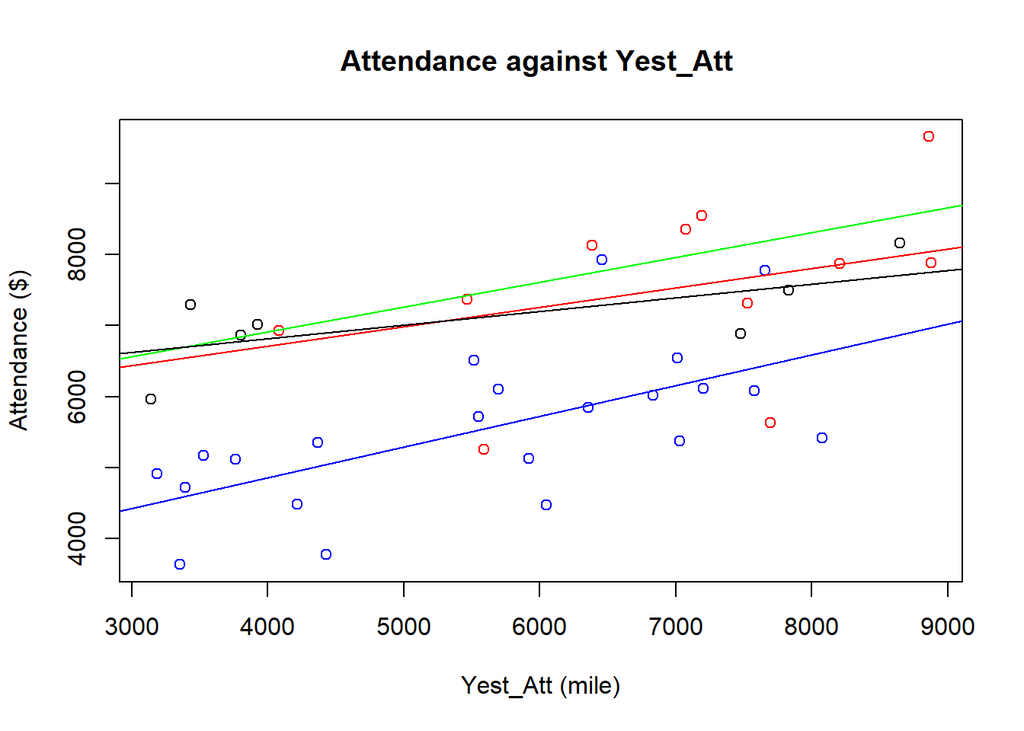

```r
Attendance <- read1817$Attendance
Yest_Att <- read1817$Yest_Att
I1 <- read1817$I1
I2 <- read1817$I2
I3 <- read1817$I3
n <- length(Attendance)
W_u <- I1 == 1
W_Attendance <- Attendance[W_u]
W_Yest_Att <- Yest_Att[W_u]
S_u <- I2 == 1
S_Attendance <- Attendance[S_u]
S_Yest_Att <- Yest_Att[S_u]
Y_u <- I3 == 1
Y_Attendance <- Attendance[Y_u]
Y_Yest_Att <- Yest_Att[Y_u]
O_u <- (I1 < 1 & I2 < 1 & I3 < 1)
O_Attendance <- Attendance[O_u]
O_Yest_Att <- Yest_Att[O_u]
plot(W_Yest_Att, W_Attendance, col = "green", main = "Attendance against Yest_Att ", xlab = "Yest_Att (mile)", ylab = "Attendance ($)", xlim=range(Yest_Att), ylim=range(Attendance))
points(S_Yest_Att, S_Attendance, col= "red")
points(Y_Yest_Att, Y_Attendance, col= "black")
points(O_Yest_Att, O_Attendance, col= "blue")
abline(lm(W_Attendance ~ W_Yest_Att), col = "green")
abline(lm(S_Attendance ~ S_Yest_Att), col= "red")
abline(lm(Y_Attendance ~ Y_Yest_Att), col= "black")
abline(lm(O_Attendance ~ O_Yest_Att), col= "blue")
```

```r
lm_17 <- lm(Attendance~., data = read1817)
summary(lm_17)
```

```
##
## Call:
## lm(formula = Attendance ~ ., data = read1817)
##
## Residuals:
##      Min       1Q   Median       3Q      Max
## -1433.27  -491.50    13.97   405.95  2058.09
##
## Coefficients:
##               Estimate Std. Error t value Pr(>|t|)
## (Intercept) 3490.46660  469.15539   7.440 1.04e-08 ***
## Yest_Att       0.36855    0.07789   4.731 3.60e-05 ***
## I1          1623.09578  492.54968   3.295  0.00226 **
## I2           733.46463  394.37182   1.860  0.07133 .
## I3          -765.54291  484.66208  -1.580  0.12321
## ---
## Signif. codes:  0 '***' 0.001 '**' 0.01 '*' 0.05 '.' 0.1 ' ' 1
##
## Residual standard error: 810.8 on 35 degrees of freedom
## Multiple R-squared:  0.7002, Adjusted R-squared:  0.6659
## F-statistic: 20.43 on 4 and 35 DF,  p-value: 9.277e-09
```

Regression model: y=3490.46660+0.36855$x_1$+1623.09578$I_1$+733.46463$I_2$−765.54291$I_3$, which y denotes attendance, $x_1$ denotes yesterday’s attendance, $I_1$ denotes weekend or not, $I_2$ denotes mostly sunny is predicted or not, $I_3$ denotes rain is predicted or not.

## b

$$H_0: \beta_1 = \beta_2 = \beta_3 = \beta_4 = 0$$
$H_1$: One or both of the parameters is not equal to zero.

since p-value of F-test = 9.28E-09 < 0.05, hence we can conclude the model is valid,

## c

$$H_0: \beta_i = 0$$
i = 3,4
$$H_0: \beta_i \neq 0$$
since p-value of $I_2$ & $I_3$ > 0.05, hence we can’t conclude that weather is a factor in determining attendance,

## d

$$H_0: \beta_i = 0$$
i = 2
$$H_0: \beta_i \neq 0$$
Yes, since $I_1$ is a factor in determining attendance, and it has positive effect on determining attendance

# Exercise 18.21

## a

```r
read1821 <- read.csv("D:\\Xr18-21.csv")
```

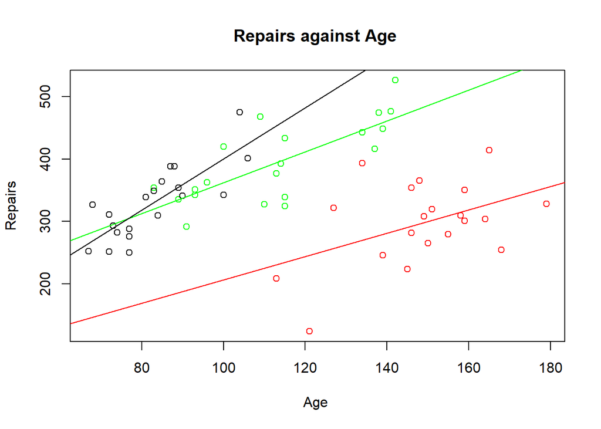

```r
Repairs <- read1821$Repairs
Age <- read1821$Age
n <- length(Repairs)
I1 <- read1821$I1
I2 <- read1821$I2
I3 <- read1821$I3
W_u <- I1 == 1
W_Repairs <- Repairs[W_u]
W_Age <- Age[W_u]
S_u <- I2 == 1
S_Repairs <- Repairs[S_u]
S_Age <- Age[S_u]
Y_u <- I3 == 1
Y_Repairs <- Repairs[Y_u]
Y_Age <- Age[Y_u]
plot(W_Age, W_Repairs, col = "green", main = "Repairs against Age ", xlab = "Age ", ylab = "Repairs", xlim=range(Age), ylim=range(Repairs))
points(S_Age, S_Repairs, col= "red")
points(Y_Age, Y_Repairs, col= "black")

abline(lm(W_Repairs ~ W_Age), col = "green")
abline(lm(S_Repairs ~ S_Age), col= "red")
abline(lm(Y_Repairs ~ Y_Age), col= "black")
```

```r
lm_21 <- lm(Repairs~., data = read1821)
summary(lm_21)
```

```
##
## Call:
## lm(formula = Repairs ~ ., data = read1821)
##
## Residuals:
##      Min       1Q   Median       3Q      Max
## -103.125  -32.830   -2.634   27.351  133.348
##
## Coefficients: (1 not defined because of singularities)
##              Estimate Std. Error t value Pr(>|t|)
## (Intercept)  119.2521    35.0004   3.407  0.00122 **
## Age            2.5382     0.4023   6.309 4.75e-08 ***
## I1           -11.7553    19.7018  -0.597  0.55314
## I2          -199.3737    30.7130  -6.492 2.39e-08 ***
## I3                 NA         NA      NA       NA
## ---
## Signif. codes:  0 '***' 0.001 '**' 0.01 '*' 0.05 '.' 0.1 ' ' 1
##
## Residual standard error: 48.59 on 56 degrees of freedom
## Multiple R-squared:  0.5938, Adjusted R-squared:  0.572
## F-statistic: 27.29 on 3 and 56 DF,  p-value: 5.236e-11
```

Regression model: y=119.2521+2.5382$x_1$−11.7553$I_1$−199.3737$I_2$, which y denotes cost of repairs, $x_1$ denotes age of machine, $I_1$ denotes welding machine or not, $I_2$ denotes lathe or not

## b

2. beta_0 = 119.2521, which is the intercept of the least square line on y . Since the data range of all the independent variables do not cover the value zero, do not interpret the intercept.

beta_1 = 2.5382, in this model, for each additional month of machine’s age, the cost of repairs increases by 2.5382 (assuming the other variables are held constant).

beta_2 = -11.7553, in this model, for a welding machine, comparing to other machine, the cost of repairs decreases by 11.7553 onaverage (assuming the other variables are held constant).

beta_3 = -199.3737, in this model, for a lathe machine, comparing to other machine, the cost of repairs decreases by 199.3737 on average (assuming the other variables are held constant).

## c

$$H_0: \beta_i = 0$$
i = 2
$$H_0: \beta_i \neq 0$$
Since p value = 0.55314 > 0.05, there is no enough evidence to conclude that whether it is welding machine is related to cost of repairs.

# Exercise 18.39

```r
read1717 <- read.csv("D:\\Xr17-17.csv")
```

## a

```r
library(olsrr)
Margin <- read1717$Margin
Number <- read1717$Number
Nearest <- read1717$Nearest
Office_Space <- read1717$Office_Space
Enrollment <- read1717$Enrollment
Income <- read1717$Income
Distance <- read1717$Distance
n <- length(Margin)
Data.Stepwise_RE <- data.frame(cbind(Number, Nearest, Office_Space, Enrollment, Income, Distance))
linearModelVar <- lm(Margin ~ Number + Nearest + Office_Space + Enrollment + Income + Distance, data = Data.Stepwise_RE)
cat(" ","\n")
```

```r
Index_step <- ols_step_both_p(linearModelVar, details = TRUE)
```

```
## Stepwise Selection Method
## ---------------------------
##
## Candidate Terms:
##
## 1. Number
## 2. Nearest
## 3. Office_Space
## 4. Enrollment
## 5. Income
## 6. Distance
##
## We are selecting variables based on p value...
##
##
## Stepwise Selection: Step 1
##
## - Office_Space added
##
##                         Model Summary
## --------------------------------------------------------------
## R                       0.501       RMSE                6.741
## R-Squared               0.251       Coef. Var          14.739
## Adj. R-Squared          0.244       MSE                45.445
## Pred R-Squared          0.220       MAE                 5.407
## --------------------------------------------------------------
##  RMSE: Root Mean Square Error
##  MSE: Mean Square Error
##  MAE: Mean Absolute Error
##
##                                ANOVA
## --------------------------------------------------------------------
##                 Sum of
##                Squares        DF    Mean Square      F         Sig.
## --------------------------------------------------------------------
## Regression    1495.889         1       1495.889    32.917    0.0000
## Residual      4453.569        98         45.445
## Total         5949.458        99
## --------------------------------------------------------------------
##
```

[output cut: 242 more lines]

```
## Regression    3009.184         4        752.296    24.307    0.0000
## Residual      2940.274        95         30.950
## Total         5949.458        99
## --------------------------------------------------------------------
##
##                                    Parameter Estimates
## -----------------------------------------------------------------------------------------
##        model      Beta    Std. Error    Std. Beta      t        Sig      lower     upper
## -----------------------------------------------------------------------------------------
##  (Intercept)    41.273         6.415                  6.434    0.000    28.538    54.009
## Office_Space     0.020         0.003        0.419     5.702    0.000     0.013     0.026
##       Number    -0.008         0.001       -0.454    -6.238    0.000    -0.010    -0.005
##       Income     0.399         0.140        0.209     2.855    0.005     0.122     0.677
##      Nearest     1.654         0.635        0.189     2.603    0.011     0.392     2.915
## -----------------------------------------------------------------------------------------
```

```r
print(Index_step)
```

```
##
##                                Stepwise Selection Summary
## -----------------------------------------------------------------------------------------
##                          Added/                   Adj.
## Step      Variable      Removed     R-Square    R-Square     C(p)        AIC        RMSE
## -----------------------------------------------------------------------------------------
##    1    Office_Space    addition       0.251       0.244    50.5810    669.4168    6.7413
##    2       Number       addition       0.432       0.421    17.1580    643.7547    5.9007
##    3       Income       addition       0.471       0.454    11.6750    638.7852    5.7282
##    4      Nearest       addition       0.506       0.485     6.7730    633.8965    5.5633
## -----------------------------------------------------------------------------------------
```

Margin = 41.273 + 0.020*Office_space - 0.008*Number + 0.399*Income + 1.654*Nearest.

## b

```r
data1717 = cbind(Number, Nearest, Office_Space, Enrollment, Income, Distance)
linearModelVar <- lm(Margin ~ data1717)
print(summary(linearModelVar))
```

```
##
## Call:
## lm(formula = Margin ~ data1717)
##
## Residuals:
##     Min      1Q  Median      3Q     Max
## -12.267  -3.022  -0.086   4.234  13.596
##
## Coefficients:
##                       Estimate Std. Error t value Pr(>|t|)
## (Intercept)          38.138575   6.992948   5.454 4.04e-07 ***
## data1717Number       -0.007618   0.001255  -6.069 2.77e-08 ***
## data1717Nearest       1.646237   0.632837   2.601   0.0108 *
## data1717Office_Space  0.019766   0.003410   5.796 9.24e-08 ***
## data1717Enrollment    0.211783   0.133428   1.587   0.1159
## data1717Income        0.413122   0.139552   2.960   0.0039 **
## data1717Distance     -0.225258   0.178709  -1.260   0.2107
## ---
## Signif. codes:  0 '***' 0.001 '**' 0.01 '*' 0.05 '.' 0.1 ' ' 1
##
## Residual standard error: 5.512 on 93 degrees of freedom
##   (1 observation deleted due to missingness)
## Multiple R-squared:  0.5251, Adjusted R-squared:  0.4944
## F-statistic: 17.14 on 6 and 93 DF,  p-value: 3.034e-13
```

```r
ANOVA_T_lm <- anova(linearModelVar)
print(ANOVA_T_lm)
```

```
## Analysis of Variance Table
##
## Response: Margin
##           Df Sum Sq Mean Sq F value    Pr(>F)
## data1717   6 3123.8  520.64  17.136 3.034e-13 ***
## Residuals 93 2825.6   30.38
## ---
## Signif. codes:  0 '***' 0.001 '**' 0.01 '*' 0.05 '.' 0.1 ' ' 1
```

# Exercise 18.49

```r
read1849 <- read.csv("D:\\Xr18-49.csv")
```